# Fiche 13 : Comprendre les métadonnées

## Que sont les métadonnées ?

Les métadonnées permettent de décrire plus précisément les données. Ce sont des **données sur les données** qui servent à faciliter la recherche d’un produit de recherche **:** lorsque vous tapez des mots clés dans une barre de recherche ou lorsque vous sélectionnez des filtres.

Si on s’imagine un jeu de données sous la forme d’une boite de conserve, alors les métadonnées équivalent à l’étiquette qui orne celle-ci et en décrit le contenu (date de fabrication, créateur etc.).

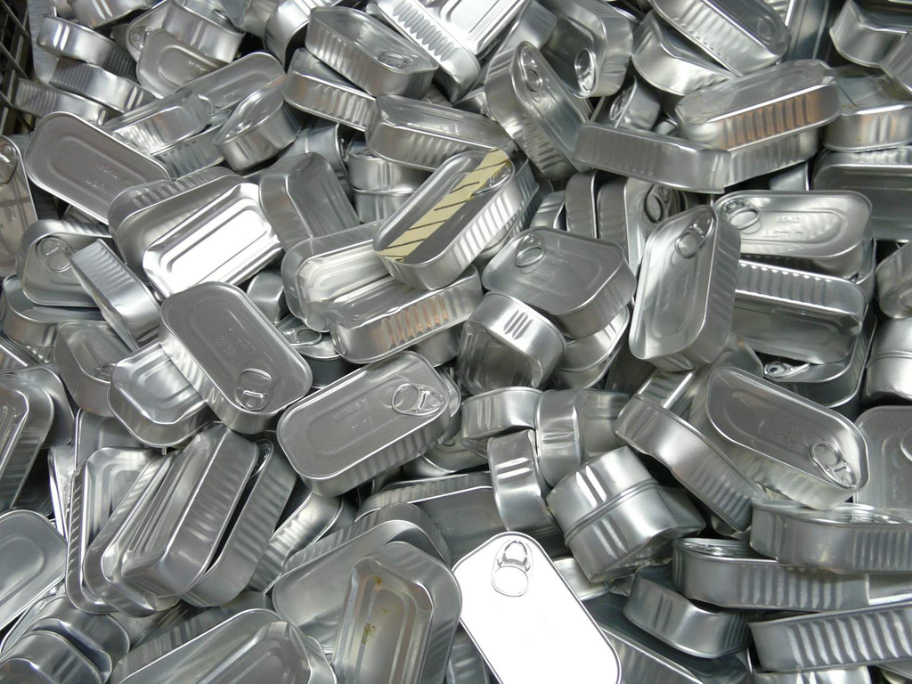

Sans métadonnées (Image par Araceli Jáuregui de Pixabay)

[figure not shown]

Avec métadonnées (Image par heberhard de Pixabay)

Les métadonnées sont donc utiles pour :

- Comprendre l’origine des données et leur contexte de création ou de collecte ;
- Améliorer le moissonnage (récupération automatique) par les machines (moteur de recherche) ;
- Garantir l’interopérabilité ;
- Connaitre les conditions de réutilisation et de partage des données ;
- Accéder à des informations très utiles lorsqu’on ne peut pas partager ses données (embargo, accès restreint) ou lors du retrait des données (données obsolètes, etc.).

Il est recommandé de renseigner les métadonnées au fur et à mesure de l’avancée du projet, avec une attention particulière :

- au moment du partage des données,
- puis à l’étape de l’archivage pérenne (des métadonnées spécifiques seront à renseigner).

Il existe deux types de métadonnées : les métadonnées embarquées et enrichies.

| Métadonnées embarquées | M&tadonnées enrichies |
| --- | --- |
| Elles sont produites **automatiquement** par les appareils (de prise de vue ou de son, de mesure…). Exemples : données GPS, type d’appareil, date, calibrage technique, etc. | Elles sont **ajoutées** par l’auteur. Exemples : mots-clés, sujet, auteur, laboratoire ou organisme, nom du projet, licence, etc. |

**Crédits :** Réseau URFIST - Inist-CNRS : [PARCOURS INTERACTIF SUR LA GESTION DES DONNÉES DE LA RECHERCHE](https://doranum.fr/enjeux-benefices/parcours-interactif-sur-la-gestion-des-donnees-de-la-recherche/)